# Prediction of restaurant ratings with Yelp dataset

HoJin Shin, Qianyu Yuan, Yi Wang

04 May 2016

All original data and cleaned data are available [here](https://drive.google.com/folderview?id=0B6Q4ObScQe3Wbm91d091amhSQ3c&usp=sharing).

In order to save time for Kniting HTML, we saveed outputs of several time-consuming processes in RDA formated files which are also available in the above link.

# INTRODUCTION

## Motivation

Yelp, a multinational corporation, publishes crowd-sourced online reviews and ratings about local businesses since its foundation in 2004. By the end of 2015, Yelp had more than 95 million reviews and a monthly average of 86 million unique visitors who visited Yelp via their mobile device [1-3]. As its proven track record indicates, Yelp is used by a great number of people as a reference to choose local businesses to go.

Yelp uses 5-star rating, 1 - 5 stars, system for a local business, based on the mean of all star ratings given to the business. In a Yelp search, a star rating is most likely to influence on users’ choice of local businesses to go as an economic research has shown that an extra half-star rating causes restaurants to sell out 19 percentage points (49%) more frequently [4]. However, people may be misled by the star rating since it may not only be influenced by quality of product or service, but also by other factors such as, but not limited to, price and atmosphere. Therefore, some users who priortize the quality of product or service compare to price might be disappointed if they find those local businesses’ high star ratings were due to high quality with high price. In addition, researches show that weather affects mood, memory and cognitive performance of people [5,6], and users’ demographic characteristics of a region are also related to the extent to which people’s engagement in diverse types of online activities [7,8]. Since these exogenous factors that are not part of businesses features are also likely to affect users’ ratings, we aim to investigate whether the ratings of businesses, especially restaurants, can be predicted not only based on characteristics of restaurants, but also those exogenous factors by using Yelp dataset.

[1] http://www.yelp.com/about  
[2] http://www.yelp.com/factsheet  
[3] http://expandedramblings.com/index.php/yelp-statistics/  
[4] M. Anderson and J. Magruder. “Learning from the Crowd: Regression Discontinuity Estimates of the Effects of an Online Review Database.” The Economic Journal. 2011.  
[5] M. A. Persinger. The weather matrix and human behavior. Praeger New York, 1980  
[6] D. Watson. Mood and temperament. Guilford Press, 2000  
[7] E. Hargittai. Digital Natives? Variation in Internet Skills and Uses among Members of the Net Generation. Sociological Inquiry, 80(1):92–113, 2010.  
[8] E. Hargittai and Y.-l. P. Hsieh. Predictors and consequences of differentiated practices on social network sites. Information, Communication & Society, 13(4):515–536, 2010.  
[9] https://www.yelp.com/dataset_challenge

## Objectives

Through this project, we sought to answer whether the current ratings and reviews in Yelp are influenced by geographic and demographic characteristics of regions, as well as by the features of restaurants (e.g. price, service etc.).

### Questions we try to answer:

- How are ratings influenced by features of restaurants and demographic characterics?
- What features of restaurants are most significantly associated with ratings of restaurants?
- How can we predict the resturant ratings or individual ratings based on restaurants features and demohraphic characteristics?
- How can we use ratings of restaurants and individual users to make recommendations for a specific user?

## Approaches

### Visualization

To explor characteristics of datasets in our anlaysis, we used:

- Visualization (ggplot/histgram/boxplot) for summarizing data and identifying potential tends;
- Smoothing (loess) to create an approximating function that attempts to capture important patterns in the data.

### Statistical methods

To predict ratings in restaurant and user datasets, we applied:

- Linear regression / Lasso / Classification and Regression Trees (CART) / Random Forest / Support Vector Machine (SVM) to model resturant ratings.
- Logistic regression / Lasso / Classification and Regression Trees (CART) / Random Forest to model individual ratings.

To make a recommendation for a specific user, we applied:

- Regularization, matrix decomposition and PCA to predict user-restaurant specific recommendations.

# DATA

## Collecting

Demographic characteristics of areas where restaurants of our analysis locate were obtained from [American FactFinder](http://factfinder.census.gov/faces/nav/jsf/pages/index.xhtml). This datasets include zip code level population, education, income, age and race information from 2009 to 2014.

Daily summaries of weather dataset for six states from 01 Feb 2005 to 24 Dec 2015, dates of the first review and the last review in our dataset, respectively, were obtained from [NOAA (National Centers For Environmental Information)](https://www.ncdc.noaa.gov/cdo-web/). The daily weather datasets include following variables, weather station, date, PRCP (Precipitation), SNWD (Snowfall), SNOW (Snow depth), TMAX (Maximum temperature), TMIN (Minimum temperature), AWND (Average daily wind speed) and WT (Weather Types).

## Data cleaning and wrangling

Due to large file size and long processing time, we linked the data cleaning and wrangling steps [here](https://github.com/QianyuYuan/BIO260-Project/blob/master/BIO260%20Final%20Project_submission_Cleaning.Rmd).

### Rationale for using sentimental positivity of review text

Although the most influencial factor of restaurant ratings are likely to be the quality of food and service, it is hard to measure since it is subjective. In addition, Yelp dataset did not have any direct measure for them. Therefore, we used review sentiment as a proxy for the quality of food and service. If a user uses more positive words than negative words, it is likely to be he/she is satisfied with the quality of food or service of a restaurant.

# EXPLORATORY ANALYSIS

To begin with, following are non-binary categorical variables in our anlaysis.

- Type (Types of food): African, American, Asian, Bars, Cafe, European, Fastfood, Latin, Middle_Eastern, Pizza, Special (Kosher and Halal), Vegetarian
- Noise: 0 = Average / 1 = Quiet / 2 = Loud / 3 = Very_loud
- Price: 1 / 2 / 3 / 4
- Wi-fi: 0 = No / 1 = free / 2 = paid
- Parking: 0 = No parking / 1 = parking(garage, validated, lot, valet) / 2 = parking(only street)

Loading datasets

```r
restaurant<-read_csv("business_whole_pos.csv")
user<-read_csv("user_whole_pos.csv")
restaurant <- restaurant %>% filter(!is.na(type) & !is.na(positivity_net))
```

## Visualization of restaurant ratings

### Maping the location of restaurants

[figure not shown]

```r
PlotOnStaticMap(lat = restaurant$latitude, lon = restaurant$longitude,  zoom =5, size = c(640,640), TrueProj=TRUE, cex=1.4, pch=19, col="red3", FUN = points, add = F)
```

### Distribution of number of restaurants

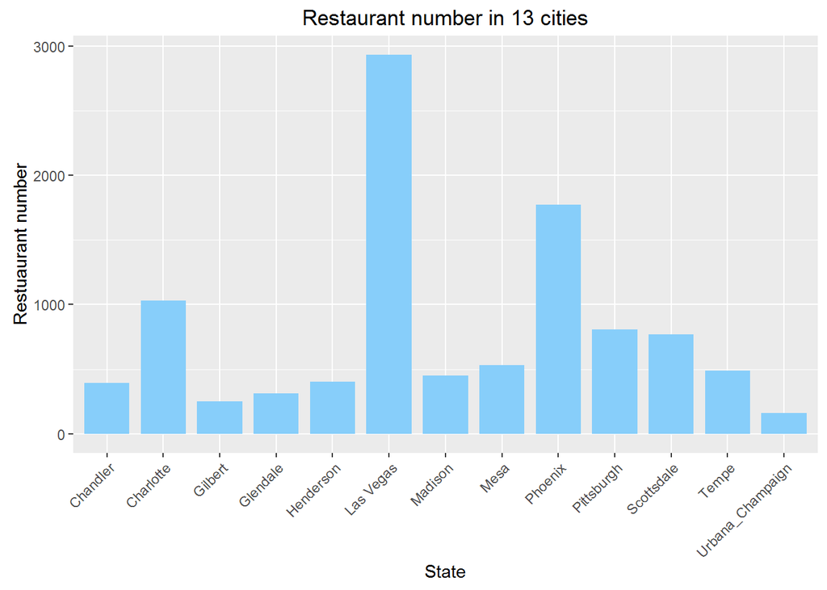

```r
## By city
restaurant%>%group_by(city)%>%ggplot( aes(city) ) + geom_bar( stat="count", width = 0.8, fill="lightskyblue")+xlab("State")+ylab("Restuaurant number")+ggtitle("Restaurant number in 13 cities")+theme(axis.text.x = element_text(angle = 45, hjust = 1))
```

Some big cities such as Las Vegas, Charlotte and Phoenix have larger number of restaurants than other smaller cities. Especially, Las Vegas has the highest number of restaurants.

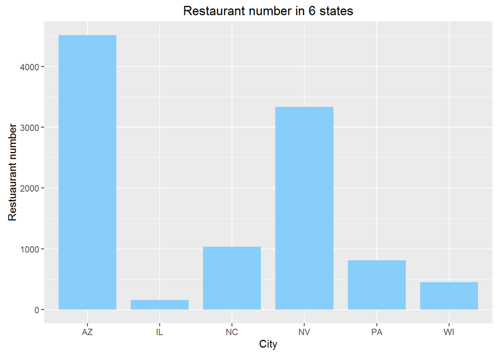

```r
## By state
restaurant%>%group_by(state)%>%ggplot( aes(state) ) + geom_bar( stat="count", width = 0.8, fill="lightskyblue")+xlab("City")+ylab("Restuaurant number")+ggtitle("Restaurant number in 6 states")
```

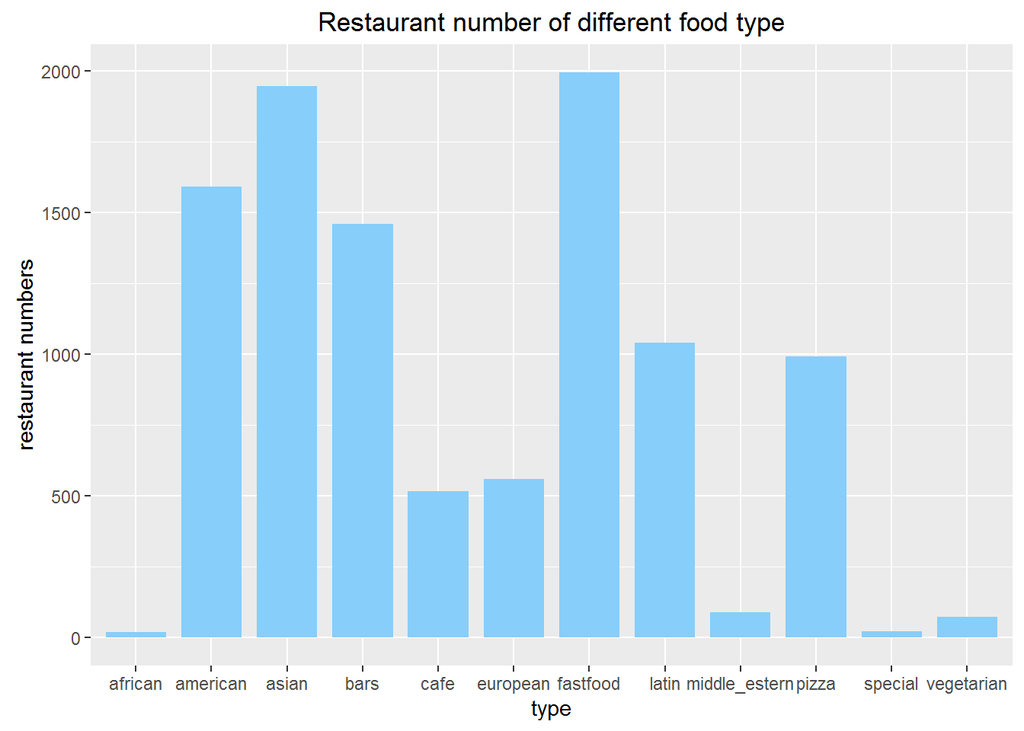

```r
## By types of food
restaurant %>% ggplot(aes(type)) + geom_bar( stat="count", width = 0.8, fill="lightskyblue")+ylab("restaurant numbers")+ggtitle("Restaurant number of different food type")
```

Types of food in our dataset are most likely to be American, Asian, bars, Fastfood, Latin and Pizza, while there are few African, Middle_Eastern, special(Kosher and Halal) and vegetarian.

### Distribution of restaurant ratings

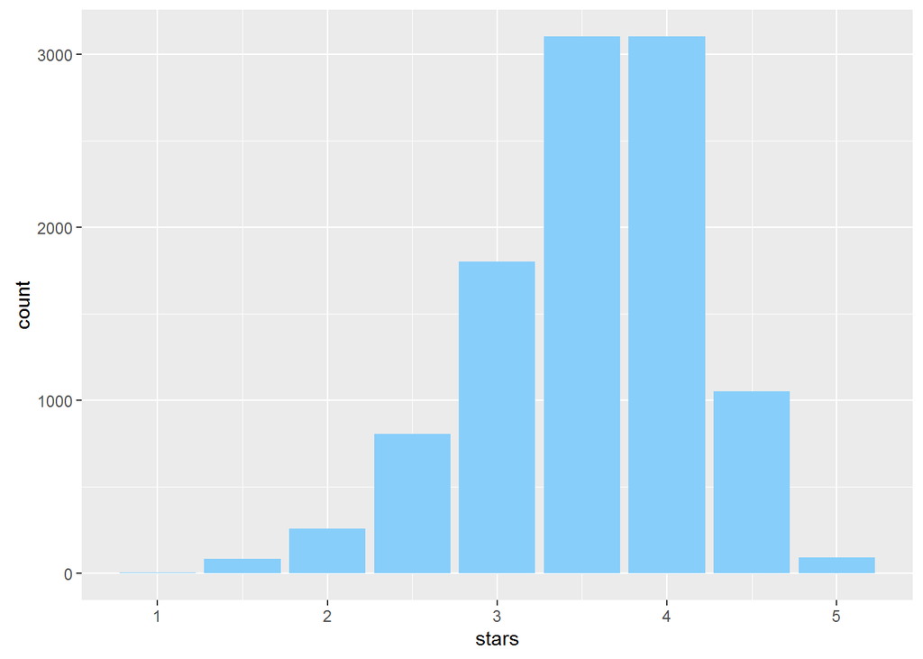

```r
restaurant %>% ggplot(aes(x = stars)) + geom_bar(fill="lightskyblue")
```

Restaurant ratings are approximately normal distributed and slightly skewed to the left.

### Restaurant: Ratings versus Features

In order to visualize the relationship between restaurant features and restaurant ratings, we caluated the difference between feature specific average ratings and the average rating of all the resturants in our dataset:
$$Average ratings (feature specific) - Average rating (allrestaurants)$$

#### Differences by type of food

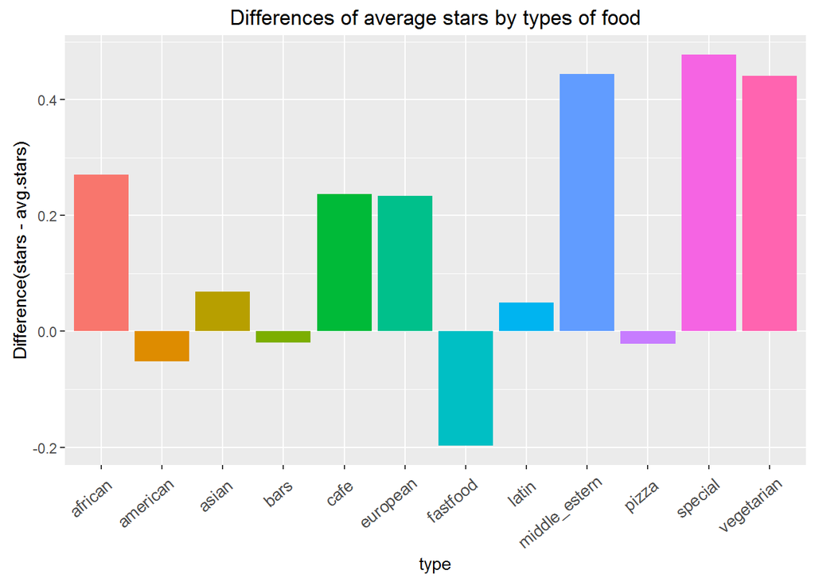

```r
mean_overall <- mean(restaurant$stars)
restaurant %>% group_by(type) %>%
  summarize(mean = mean(stars), diff = mean - mean_overall) %>% ggplot( aes(type, diff, label = type) )+
  geom_bar( stat="identity", position="identity", aes(fill = type)) +
  theme(axis.text.x = element_text(angle = 40, size = 10, hjust = 0.9, vjust = 0.9),legend.position="none") +
  ggtitle("Differences of average stars by types of food") + ylab("Difference(stars - avg.stars)")
```

Ratings of most types of food are above the average, while ratings of fast food is distinctly below the average.

#### Differences by price

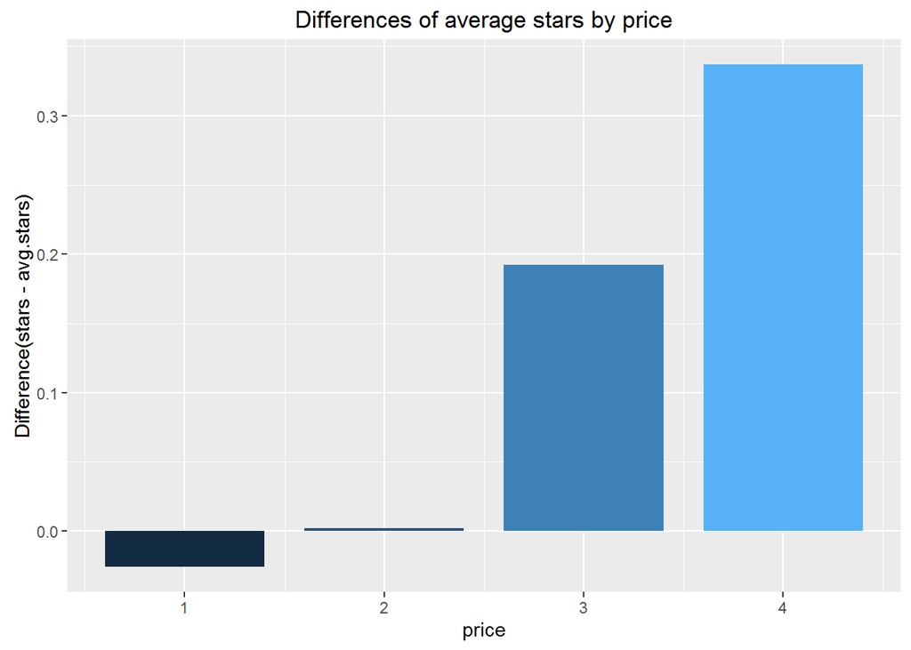

```r
restaurant %>% group_by(price) %>%
  summarize(mean = mean(stars), diff = mean - mean_overall) %>%
  ggplot(aes(price, diff, label = price,width=0.8 )) +
  geom_bar( stat="identity", position="identity", aes(fill = price)) +
  ggtitle("Differences of average stars by price") + ylab("Difference(stars - avg.stars)")+theme(legend.position="none")
```

Restaurants with higher price have higher average ratings.

#### Differences by the level of noise

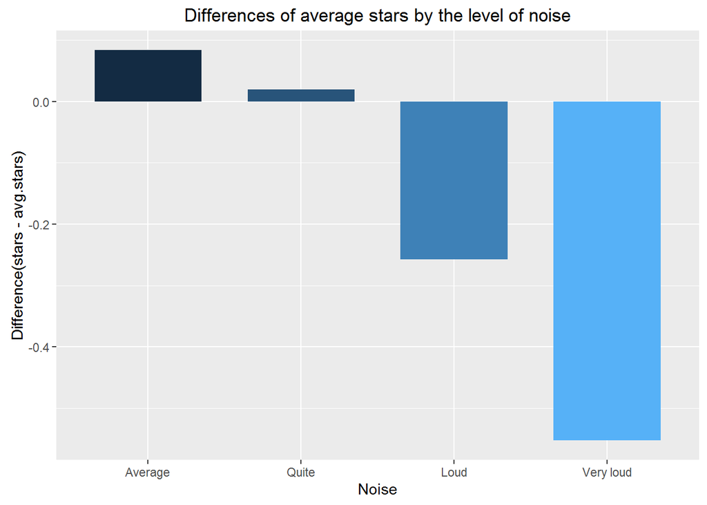

```r
restaurant %>% group_by(noise) %>%
  summarize(mean = mean(stars), diff = mean - mean_overall) %>%
  ggplot( aes(as.factor(noise), diff, label = noise,width=0.7) ) +
  geom_bar( stat="identity", position="identity", aes(fill = noise)) +
  ggtitle("Differences of average stars by the level of noise") + ylab("Difference(stars - avg.stars)")+xlab("Noise")+theme(legend.position="none")+
  scale_x_discrete(labels=c( "Average","Quite", "Loud","Very loud"))
```

Restaurants with loud noise tend to have lower ratings.

#### Differences by the availability of parking

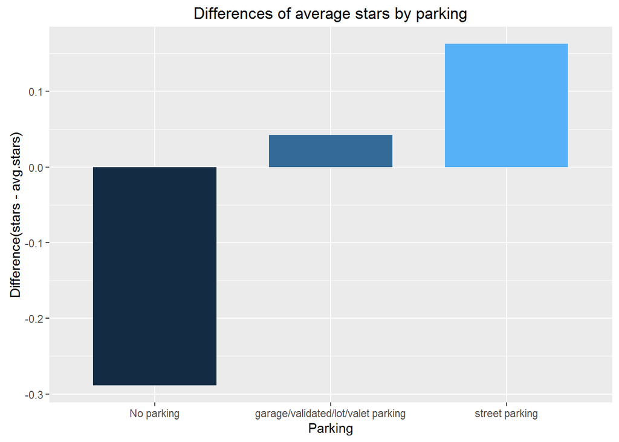

```r
restaurant %>% group_by(parking) %>%
  summarize(mean = mean(stars), diff = mean - mean_overall) %>%
  ggplot( aes(as.factor(parking), diff, label = as.factor(parking),width=0.7) ) +
  geom_bar( stat="identity", position="identity", aes(fill = parking)) +
  ggtitle("Differences of average stars by parking") + ylab("Difference(stars - avg.stars)")+xlab("Parking")+theme(legend.position="none")+
  scale_x_discrete(labels=c("0" = "No parking", "1" = "garage/validated/lot/valet parking","2" = "street parking"))
```

Restaurants with no parking have lower average ratings.

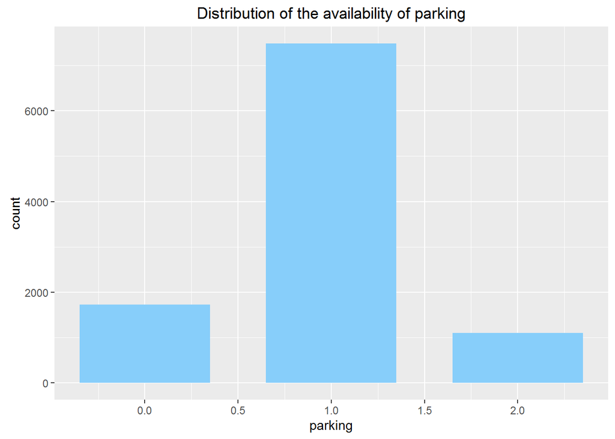

```r
restaurant%>%ggplot(aes(parking))+geom_bar(fill="lightskyblue",width=0.7)+
  ggtitle("Distribution of the availability of parking")
```

Most restaurants provide garage/validated/lot/valet parking.

#### Differences by the availability of Wi-Fi

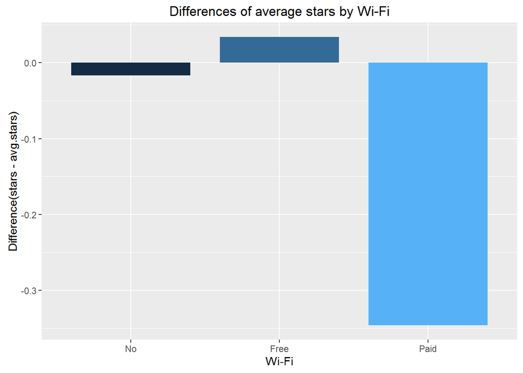

```r
restaurant %>% group_by(wifi) %>% summarize(mean = mean(stars), diff = mean - mean_overall) %>% ggplot( aes(as.factor(wifi), diff, label = wifi,width=0.8) ) +
  geom_bar( stat="identity", position="identity", aes(fill = wifi)) +
  ggtitle("Differences of average stars by Wi-Fi") + ylab("Difference(stars - avg.stars)")+xlab("Wi-Fi")+theme(legend.position="none")+
  scale_x_discrete(labels=c( "No","Free","Paid"))
```

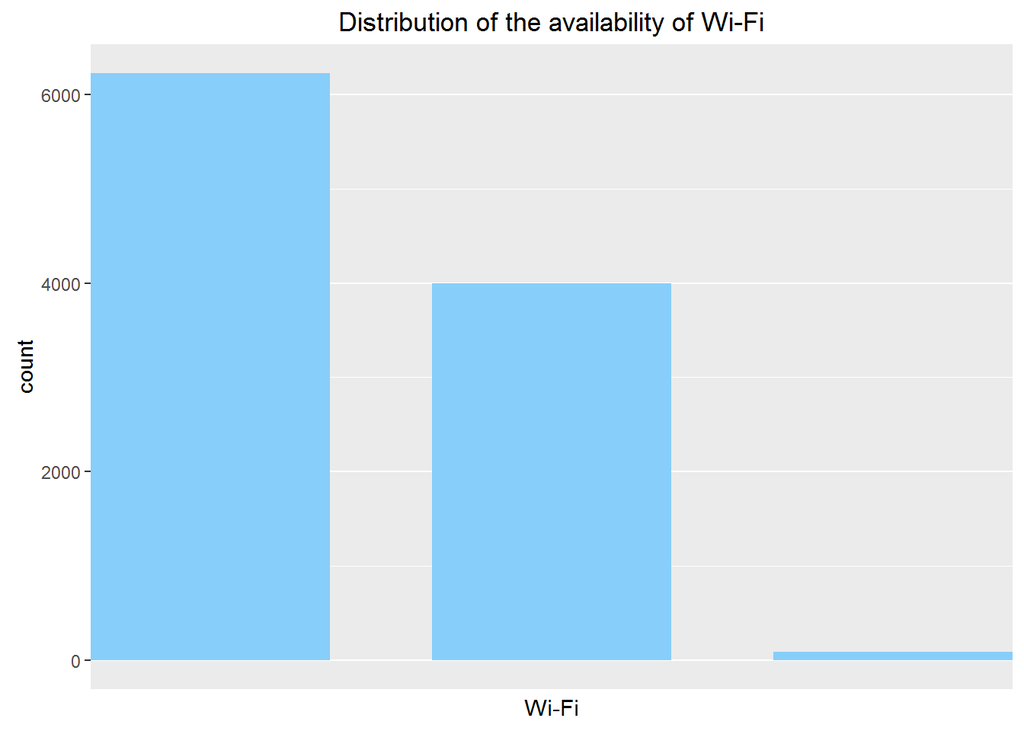

```r
restaurant%>%ggplot(aes(wifi))+geom_bar(fill="lightskyblue",width=0.7)+
  ggtitle("Distribution of the availability of Wi-Fi")+
  xlab("Wi-Fi")+
  scale_x_discrete(labels=c( "No","Free","Paid"))
```

Resturants with Paid Wi-Fi tend to be rated lower, while average ratings for restaurants with or without free Wi-fi are similar. However, the results are likely to be baised becuase there are few restaurants which provide paid Wi-fi.

### Restaurant: Review_counts versus Ratings

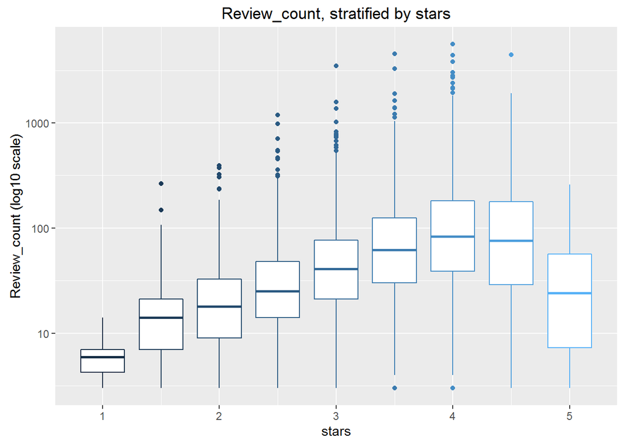

```r
restaurant %>% group_by(stars) %>%
  ggplot(aes(stars, review_count, col=stars, group=stars)) + geom_boxplot() +
  scale_y_log10() +
  ggtitle("Review_count, stratified by stars") + ylab("Review_count (log10 scale)")+theme(legend.position="none")
```

Ratings of restaurants seem to be related to the number of reviews as shown in this plot where the number of reviews keep increasing from 1 star to 4 stars and decreasing afterward.

### Restaurant: Positive sentiment of review text versus Ratings

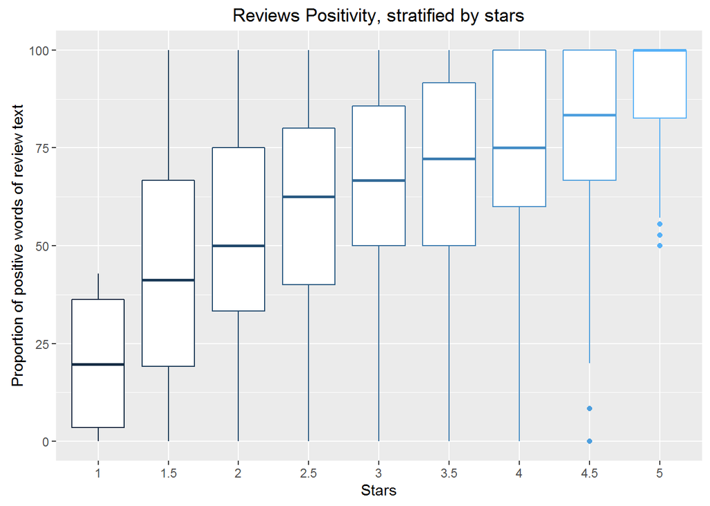

```r
restaurant%>%group_by(stars)%>%
  ggplot(aes(x=as.factor(stars), y=positivity_net,col=stars))+
  geom_boxplot()+xlab("Stars")+ylab("Proportion of positive words of review text")+
  ggtitle("Reviews Positivity, stratified by stars")+
  theme(legend.position="none")
```

The results seem to be consistent with the common sense that ratings might be subjective, and thus, users’ emotion might be reflected in their reviews. Therefore, this makes sense that higher positivity of reviews are related to higer ratings.

### Restaurant: Demographic characteristics versus Ratings

In order to visualize the relationship between demograhpic characteristics of restaurants and their ratings, we are assuming that the shape of relationship is *smooth* and using local weighted regression (loess) smoothing to plot the relationship.

Here we are using average ratings of restaurants in the same zip code area as an outcome since demographic characteristics in our dataset are clustered by zip code.

#### Population density versus Average ratings by zip code

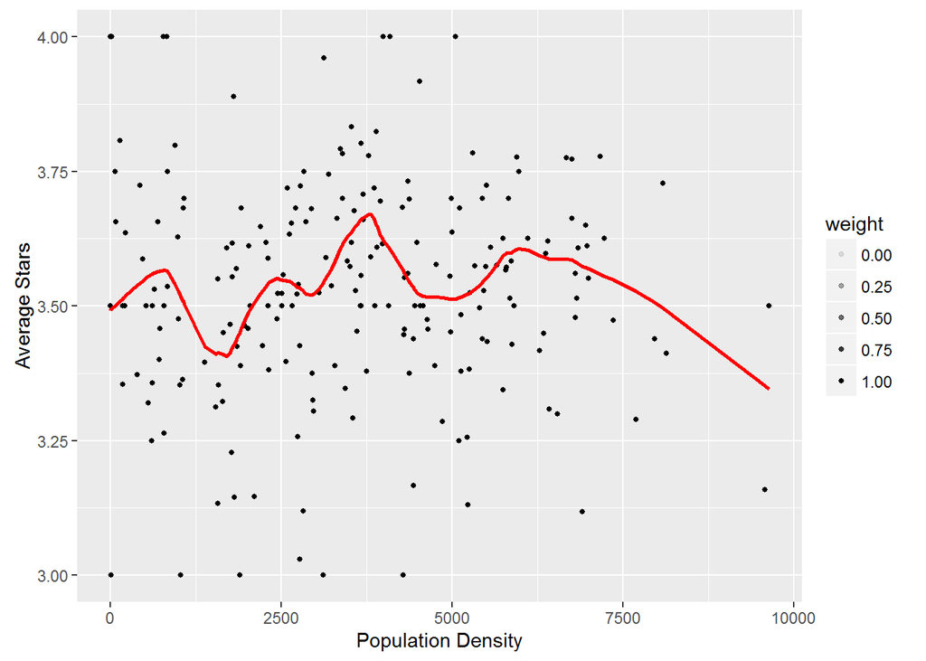

```r
library(broom)
span <- 0.2
pop1<-restaurant%>%group_by(popdensity_zip)%>%
  filter(popdensity_zip<10000)%>%
  summarize(mean=mean(stars))
pop2 <- pop1 %>%
  inflate(center = unique(pop1$popdensity_zip)) %>%
  mutate(dist = abs(popdensity_zip - center)) %>%
  filter(rank(dist) / n() <= span) %>%
  mutate(weight = (1 - (dist / max(dist)) ^ 3) ^ 3)
loess_fit1 <- augment(loess(mean~popdensity_zip, degree=1, span = span, data=pop1))
ggplot(pop2, aes(popdensity_zip, mean)) +
  geom_point(aes(alpha = weight, frame = center),cex=1) +
  geom_line(aes(x=popdensity_zip, y = .fitted, frame = popdensity_zip, cumulative = TRUE), data = loess_fit1, color = "red",lwd=1) + ylim(3,4)+xlab("Population Density")+ylab("Average Stars")
```

There seems to be no increasing or decreasing trend. This makes sense because population density is not likely to be associated with how spacious a restaurant is.

#### Income versus Average ratings by zip code

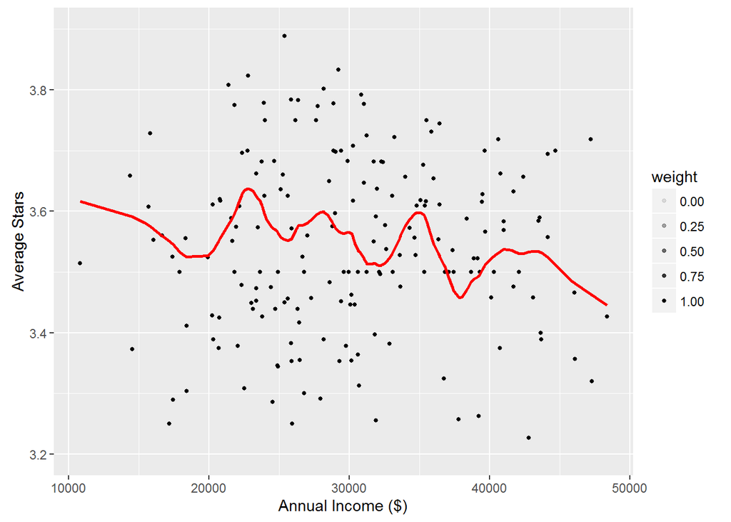

```r
income1<-restaurant%>%group_by(income_zip)%>%
  filter(income_zip>10000 & income_zip<50000)%>%
  summarize(mean=mean(stars))
income2 <- income1 %>%
  inflate(center = unique(income1$income_zip)) %>%
  mutate(dist = abs(income_zip - center)) %>%
  filter(rank(dist) / n() <= span) %>%
  mutate(weight = (1 - (dist / max(dist)) ^ 3) ^ 3)
loess_fit2 <- augment(loess(mean~income_zip, degree=1, span = span, data=income1))
ggplot(income2, aes(income_zip, mean)) +
  geom_point(aes(alpha = weight, frame = center),cex=1) +
  geom_line(aes(x=income_zip, y = .fitted, frame = income_zip, cumulative = TRUE), data = loess_fit2, color = "red",lwd=1) + ylim(3.2,3.9)+xlab("Annual Income ($)")+ylab("Average Stars")
```

Although average ratings tend to decrease slighlty as annual income increases, the association is not clear. Therefore, we restriced the dataset to restaurants with higer price to see if people with higer annual income would rate restaurants with higher price harsher than people with lower annual income.

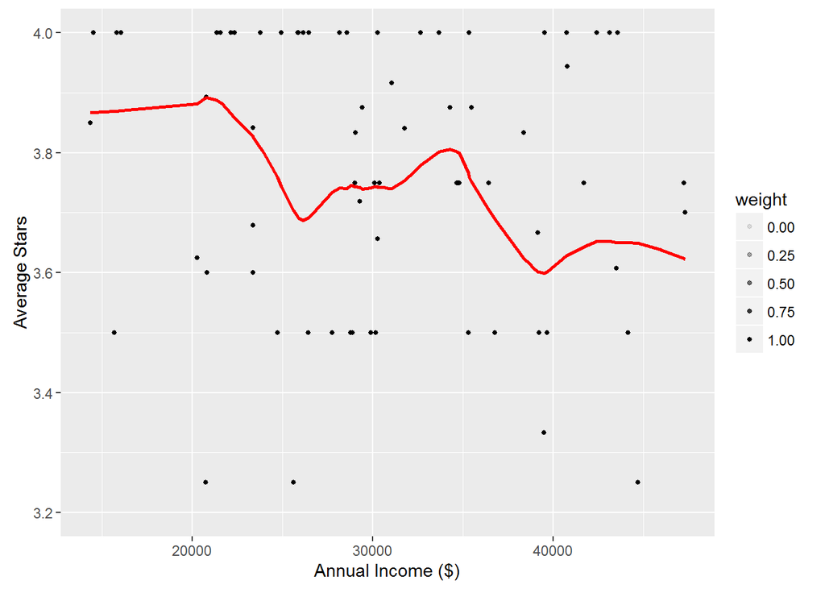

```r
## Restaurants with price 3 & 4
span2=0.3
income3<-restaurant%>%filter(price==3 | price==4)%>%
  group_by(income_zip)%>%
  filter(income_zip>10000 & income_zip<50000)%>%
  summarize(mean=mean(stars))
income4 <- income3 %>%
  inflate(center = unique(income3$income_zip)) %>%
  mutate(dist = abs(income_zip - center)) %>%
  filter(rank(dist) / n() <= span2) %>%
  mutate(weight = (1 - (dist / max(dist)) ^ 3) ^ 3)
loess_fit_2 <- augment(loess(mean~income_zip, degree=1, span = span2, data=income3))
ggplot(income4, aes(income_zip, mean)) +
  geom_point(aes(alpha = weight, frame = center),cex=1) +
  geom_line(aes(x=income_zip, y = .fitted, frame = income_zip, cumulative = TRUE), data = loess_fit_2, color = "red",lwd=1) + ylim(3.2,4)+xlab("Annual Income ($)")+ylab("Average Stars")
```

Althogh the slope does not seem to be changed much, people with higher annual income seem to rate harsher than others.

#### Restaurant: Level of education versus Average ratings by zip code

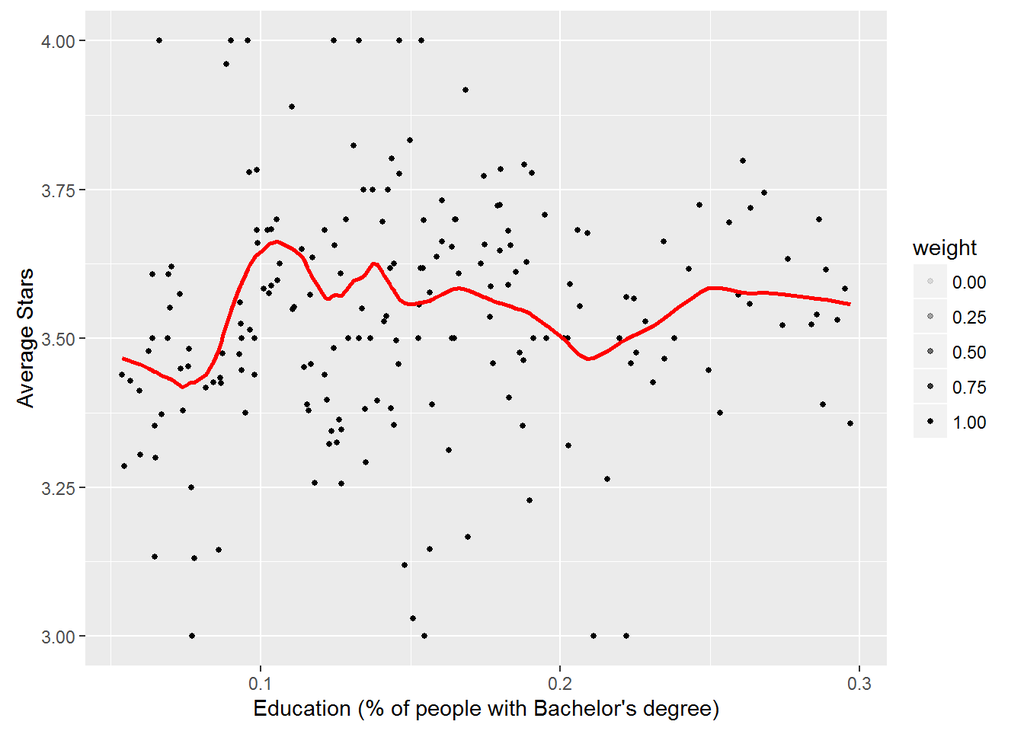

```r
edu1<-restaurant%>%group_by(education_zip)%>%
  filter(education_zip>0.05 & education_zip<0.3)%>%
  summarize(mean=mean(stars))
edu2 <- edu1 %>%
  inflate(center = unique(edu1$education_zip)) %>%
  mutate(dist = abs(education_zip - center)) %>%
  filter(rank(dist) / n() <= span) %>%
  mutate(weight = (1 - (dist / max(dist)) ^ 3) ^ 3)
loess_fit3 <- augment(loess(mean~education_zip, degree=1, span = span, data=edu1))
ggplot(edu2, aes(education_zip, mean)) +
  geom_point(aes(alpha = weight, frame = center),cex=1) +
  geom_line(aes(x=education_zip, y = .fitted, frame = education_zip, cumulative = TRUE), data = loess_fit3, color = "red",lwd=1) + ylim(3,4)+xlab("Education (% of people with Bachelor's degree)")+ylab("Average Stars")
```

There seems to be no trend. Considering the fact that about 60% of Yelp users are college educated, Yelp users might be different from people live around a restaurant, and thus, no-association may be possible.

#### Restaurant: Age versus Average ratings by zip code

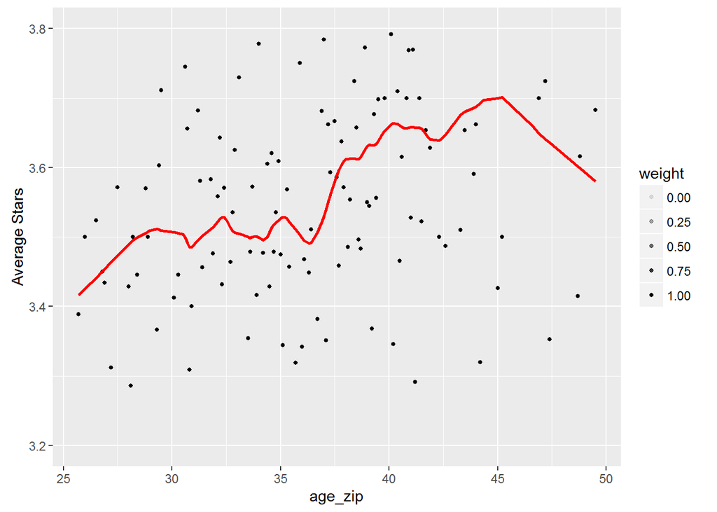

```r
age1<-restaurant%>%group_by(age_zip)%>%
  filter(age_zip>25 & age_zip<50)%>%
  summarize(mean=mean(stars))
age2 <- age1 %>%
  inflate(center = unique(age1$age_zip)) %>%
  mutate(dist = abs(age_zip - center)) %>%
  filter(rank(dist) / n() <= span) %>%
  mutate(weight = (1 - (dist / max(dist)) ^ 3) ^ 3)
loess_fit4 <- augment(loess(mean~age_zip, degree=1, span = span, data=age1))
ggplot(age2, aes(age_zip, mean)) +
  geom_point(aes(alpha = weight, frame = center),cex=1) +
  geom_line(aes(x=age_zip, y = .fitted, frame = age_zip, cumulative = TRUE), data = loess_fit4, color = "red",lwd=1) + ylim(3.2,3.8)+ylab("Average Stars")
```

Although older people seem to be associated with higher ratings, considering that most of Yelp users might be relatively younger, we are not sure about this association.

## Visualization of user ratings

### Distribution of individual user ratings

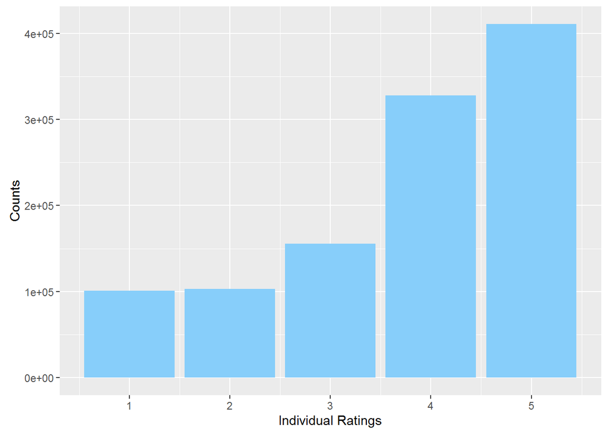

```r
user %>% ggplot(aes(x = star_individual,width=0.8)) + geom_bar(fill="lightskyblue")+
  ylab("Counts")+xlab("Individual Ratings")
```

Unlike the distribution of restaurant ratings, the distribution of individual user ratings is absolutely skewed to the left.

### User: Postive sentiment of review contents versus Ratings

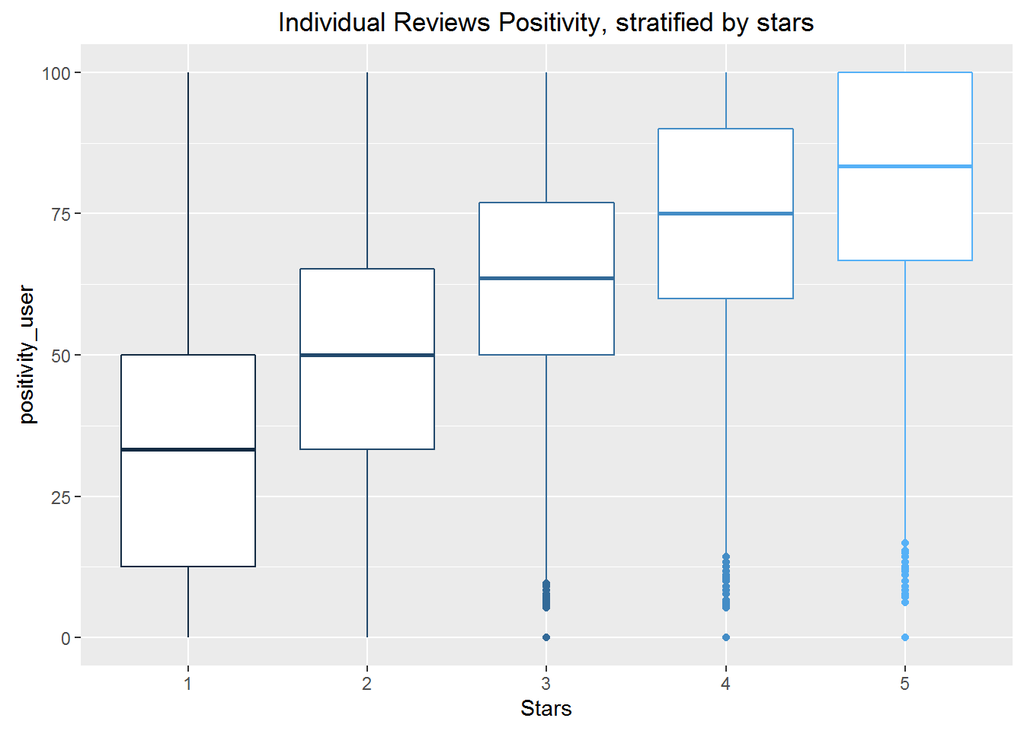

```r
user%>%group_by(star_individual)%>%ggplot(aes(x=as.factor(star_individual), y=positivity_user,col=star_individual))+
  geom_boxplot()+xlab("Stars")+
  ggtitle("Individual Reviews Positivity, stratified by stars")+
  theme(legend.position="none")
```

Review texts with higher proportion of positive words seem to be associated with higher ratings.

### User: Weather versus Individual Ratings

#### Max/Min temperature versus Individual Ratings

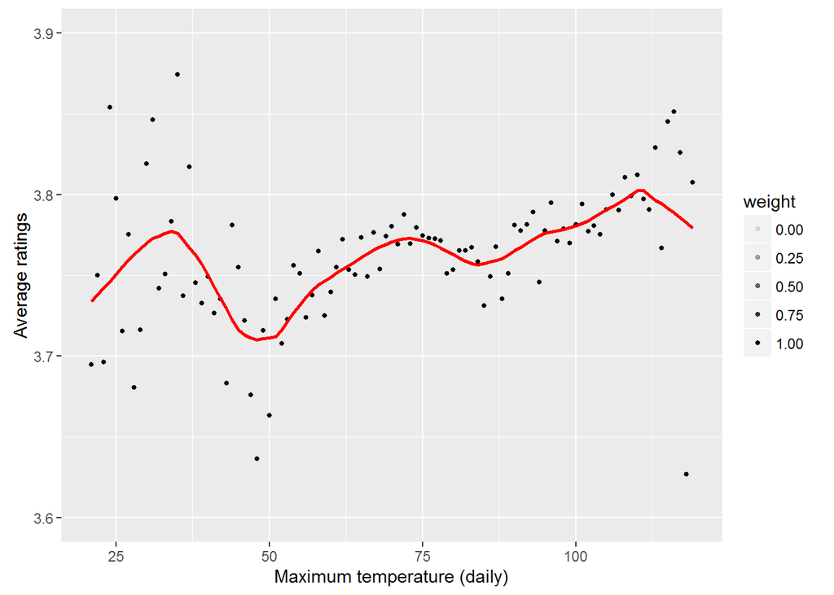

```r
##Maximum temperature versus individual ratings
tmax1<-user%>%group_by(TMAX)%>%
  filter(TMAX>20)%>%
  summarize(mean=mean(star_individual))
tmax2 <- tmax1 %>%
  inflate(center = unique(tmax1$TMAX)) %>%
  mutate(dist = abs(TMAX - center)) %>%
  filter(rank(dist) / n() <= span) %>%
  mutate(weight = (1 - (dist / max(dist)) ^ 3) ^ 3)
loess_fit5 <- augment(loess(mean~TMAX, degree=1, span = span, data=tmax1))
ggplot(tmax2, aes(TMAX, mean)) +
  geom_point(aes(alpha = weight, frame = center),cex=1) +
  geom_line(aes(x=TMAX, y = .fitted, frame = TMAX, cumulative = TRUE), data = loess_fit5, color = "red",lwd=1) + ylim(3.6,3.9)+xlab("Maximum temperature (daily)")+ylab("Average ratings")
```

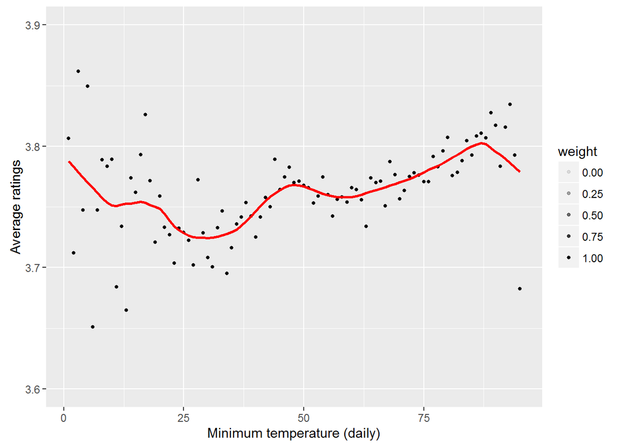

```r
##Minimum temperature versus individual ratings
tmin1<-user%>%group_by(TMIN)%>%
  filter(TMIN>0)%>%
  summarize(mean=mean(star_individual))
tmin2 <- tmin1 %>%
  inflate(center = unique(tmin1$TMIN)) %>%
  mutate(dist = abs(TMIN - center)) %>%
  filter(rank(dist) / n() <= span) %>%
  mutate(weight = (1 - (dist / max(dist)) ^ 3) ^ 3)
loess_fit6 <- augment(loess(mean~TMIN, degree=1, span = span, data=tmin1))
ggplot(tmin2, aes(TMIN, mean)) +
  geom_point(aes(alpha = weight, frame = center),cex=1) +
  geom_line(aes(x=TMIN, y = .fitted, frame = TMIN, cumulative = TRUE), data = loess_fit6, color = "red",lwd=1) + ylim(3.6,3.9)+xlab("Minimum temperature (daily)")+ylab("Average ratings")
```

Maximum and minimum daily temperature seem to be associated with average individual ratings.

#### User: Differences of average stars by weather type

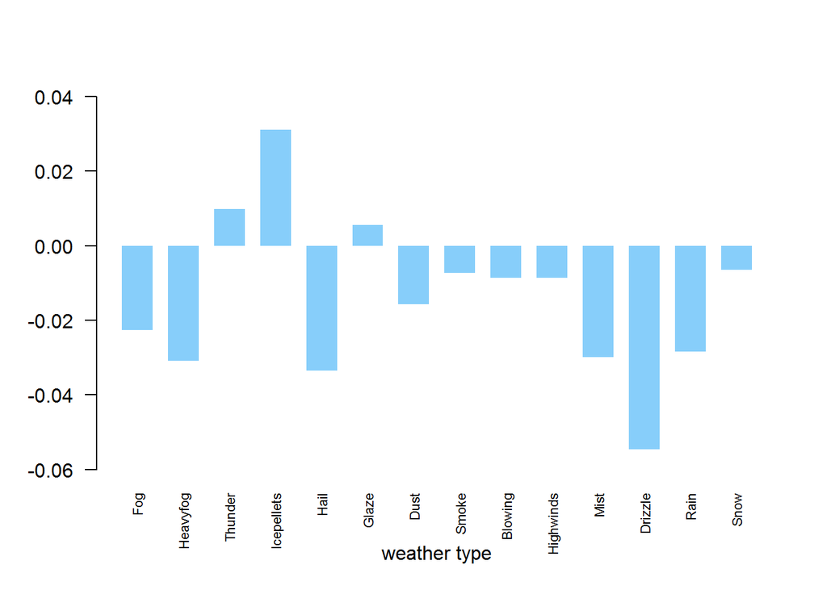

```r
average<-user%>%filter(WT01!=1 & WT02!=1 & WT03!=1 & WT04!=1 & WT05!=1 & WT06!=1 & WT07!=1 & WT08!=1 & WT09!=1 & WT13!=1 & WT14!=1 & WT16!=1 & WT18!=1)%>%
  summarize(mean=mean(star_individual,na.rm=TRUE))
average<-average$mean
average=mean(user$star_individual)
weather<-user%>%select(WT09:WT10,star_individual)%>%
summarize(Fog=sum(WT01*star_individual)/sum(WT01)-average,
          Heavyfog=sum(WT02*star_individual)/sum(WT02)-average,
          Thunder=sum(WT03*star_individual)/sum(WT03)-average,
          Icepellets=sum(WT04*star_individual)/sum(WT04)-average,
          Hail=sum(WT05*star_individual)/sum(WT05)-average,
          Glaze=sum(WT06*star_individual)/sum(WT06)-average,
          Dust=sum(WT07*star_individual)/sum(WT07)-average,
          Smoke=sum(WT08*star_individual)/sum(WT08)-average,
          Blowing=sum(WT09*star_individual)/sum(WT09)-average,
          Highwinds=sum(WT09*star_individual)/sum(WT09)-average,
          Mist=sum(WT13*star_individual)/sum(WT13)-average,
          Drizzle=sum(WT14*star_individual)/sum(WT14)-average,
          Rain=sum(WT16*star_individual)/sum(WT16)-average,
          Snow=sum(WT18*star_individual)/sum(WT18)-average)
change<-as.matrix(weather)
barplot(change,space = 0.5, axisnames = TRUE,cex.names = 0.7, las=2,xlab="weather type",col="lightskyblue",ylim=c(-0.06,0.04),border=NA)
```

# MODELING

We separately performed analyses for restaurant and user datasets.

## Restaurant level anlaysis

To explore relationships between the outcome, restaurant ratings, and variables as well as among attributes, we fitted models. Since star rating of restaurants starts at 1.0 up to 5.0 by 0.5 scale and its distribution looked pretty normal from the bar plot, we treated it as a continuous variable. Our analyses include:

- Exploring the statistically siginificant variables associated with the average ratings of restaurant using stepwise and Lasso variable selection methods.
- Using regression trees / random forest/ Support Vector Machine (SVM) for prediction of restaurant ratings

### Partitioning the dataset

To fit and evaluate models, we partitioned the dataset to training and testing. Also, non-binary categorical variables were changed to factor.

```r
restaurant <- restaurant %>% filter(!is.na(type) & !is.na(positivity_net))
restaurant[, c(2:4,23:26,34:37)] <- lapply(restaurant[, c(2:4,23:26,34:37)], as.factor)

inTrain <- createDataPartition(y=restaurant$stars, p=0.80, list=FALSE)
training <- restaurant[inTrain,]
testing  <- restaurant[-inTrain,]
```

*Note: In predicting steps of each modeling, there are warning messages, “contrasts dropped from factor C(type, base = 2)”. This message seems to be created due to limited sample size of testing dataset.*

### Multivariable linear regression - stepwise

```r
## We fitted a stepwise linear regression model
rest_linear_fit <- lm(stars ~ C(type, base=2) + review_count + takeout + reservation + outdoorseating + waiterservice + creditcards + goodforkids + goodforgroups + goodfordessert + goodforlatenight + goodforlunch + goodfordinner + goodforbrunch + goodforbreakfast + price + parking + noise + alcohol + white + black + native_american + asian + other + wifi + popdensity_zip + income_zip + education_zip + age_zip + positivity_net, data = training)

## Choosing variables using stepwise
rest_linear_fit_step <- step(rest_linear_fit)
```

```r
summary(rest_linear_fit_step)
```

```
##
## Call:
## lm(formula = stars ~ C(type, base = 2) + review_count + takeout +
##     outdoorseating + creditcards + goodforkids + goodforgroups +
##     goodfordessert + goodforlatenight + goodforlunch + goodfordinner +
##     goodforbrunch + goodforbreakfast + price + parking + noise +
##     asian + wifi + popdensity_zip + income_zip + positivity_net,
##     data = training)
##
## Residuals:
##     Min      1Q  Median      3Q     Max
## -2.5112 -0.3539  0.0338  0.3927  1.7429
##
## Coefficients:
##                       Estimate Std. Error t value Pr(>|t|)
## (Intercept)          3.178e+00  7.285e-02  43.618  < 2e-16 ***
## C(type, base = 2)1   2.612e-01  1.495e-01   1.747 0.080729 .
## C(type, base = 2)3   1.012e-01  2.364e-02   4.279 1.90e-05 ***
## C(type, base = 2)4   2.937e-02  2.576e-02   1.140 0.254150
## C(type, base = 2)5   2.292e-01  3.332e-02   6.878 6.50e-12 ***
## C(type, base = 2)6   2.050e-01  3.229e-02   6.348 2.30e-10 ***
## C(type, base = 2)7  -7.978e-02  2.361e-02  -3.380 0.000728 ***
## C(type, base = 2)8   1.152e-01  2.681e-02   4.296 1.76e-05 ***
## C(type, base = 2)9   4.000e-01  6.943e-02   5.761 8.68e-09 ***
## C(type, base = 2)10  5.639e-02  2.776e-02   2.031 0.042237 *
## C(type, base = 2)11  3.062e-01  1.368e-01   2.237 0.025301 *
## C(type, base = 2)12  3.768e-01  7.756e-02   4.857 1.21e-06 ***
## review_count         4.902e-04  3.324e-05  14.746  < 2e-16 ***
## takeout              5.040e-02  3.380e-02   1.491 0.135977
## outdoorseating       6.845e-02  1.407e-02   4.864 1.17e-06 ***
## creditcards         -3.064e-01  4.668e-02  -6.563 5.59e-11 ***
## goodforkids         -5.141e-02  2.299e-02  -2.236 0.025346 *
## goodforgroups        5.466e-02  2.420e-02   2.258 0.023956 *
## goodfordessert       1.558e-01  3.613e-02   4.314 1.62e-05 ***
## goodforlatenight    -8.323e-02  2.721e-02  -3.058 0.002234 **
## goodforlunch         3.028e-02  1.586e-02   1.910 0.056216 .
## goodfordinner       -3.019e-02  1.691e-02  -1.786 0.074157 .
## goodforbrunch        9.074e-02  2.277e-02   3.985 6.79e-05 ***
## goodforbreakfast    -8.249e-02  2.357e-02  -3.499 0.000469 ***
## price2              -1.033e-01  1.559e-02  -6.623 3.74e-11 ***
## price3               5.365e-02  4.267e-02   1.257 0.208675
## price4               2.390e-01  7.629e-02   3.133 0.001739 **
## parking1             2.370e-01  1.961e-02  12.082  < 2e-16 ***
## parking2             3.388e-01  2.764e-02  12.259  < 2e-16 ***
## noise1              -8.938e-02  1.683e-02  -5.312 1.12e-07 ***
## noise2              -2.898e-01  2.949e-02  -9.827  < 2e-16 ***
## noise3              -4.865e-01  4.323e-02 -11.254  < 2e-16 ***
## asian               -5.906e-03  1.276e-03  -4.628 3.75e-06 ***
## wifi1                1.272e-02  1.404e-02   0.906 0.364988
## wifi2               -2.761e-01  6.949e-02  -3.974 7.14e-05 ***
## popdensity_zip       7.541e-06  2.857e-06   2.639 0.008323 **
## income_zip           1.388e-06  8.160e-07   1.702 0.088878 .
## positivity_net       5.227e-03  2.426e-04  21.549  < 2e-16 ***
## ---
## Signif. codes:  0 '***' 0.001 '**' 0.01 '*' 0.05 '.' 0.1 ' ' 1
##
## Residual standard error: 0.5729 on 8209 degrees of freedom
## Multiple R-squared:  0.2039, Adjusted R-squared:  0.2003
## F-statistic: 56.83 on 37 and 8209 DF,  p-value: < 2.2e-16
```

```r
rest_linear_fit_step_coef <- tidy(rest_linear_fit_step, conf.int = TRUE)
rest_linear_pred_step <- predict(rest_linear_fit_step, testing)
rest_linear_rmse_step <- RMSE(testing$stars, rest_linear_pred_step)
rest_linear_rmse_step
```

```
## [1] 0.5780128
```

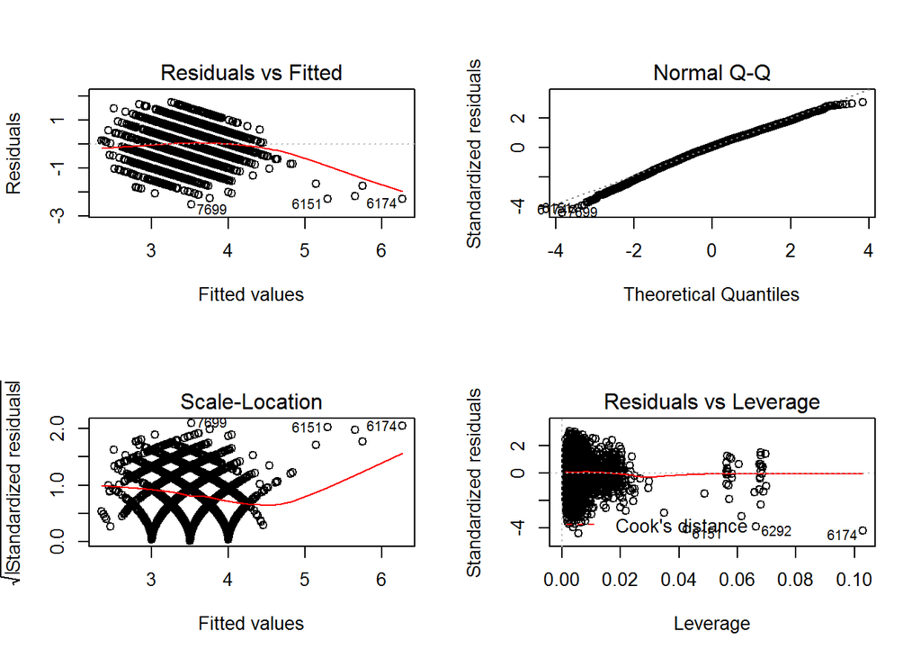

```r
par(mfrow=c(2,2));plot(rest_linear_fit_step)
```

```r
rmse_results <- data_frame(method = "Restaurant Stepwise Linear Regression", RMSE = rest_linear_rmse_step)
```

### Multivariable linear regression - Lasso

```r
xfactors <- model.matrix(stars ~ C(type, base=2) + takeout + reservation + outdoorseating + waiterservice + creditcards + goodforkids + goodforgroups + goodfordessert + goodforlatenight + goodforlunch + goodfordinner + goodforbrunch + goodforbreakfast + price + parking + noise + alcohol + wifi, training)[,-1]
x <- as.matrix(data.frame(training$review_count, training$white, training$black, training$native_american, training$asian, training$other, training$popdensity_zip, training$income_zip, training$education_zip, training$age_zip, training$positivity_net, xfactors))

glmmod<-glmnet(x,training$stars,alpha=.5,family='gaussian')
cvfit <- glmnet::cv.glmnet(x, training$stars)
rest_linear_fit1_lasso_coef <- coef(cvfit, s = "lambda.1se")
print(rest_linear_fit1_lasso_coef)
```

```
## 47 x 1 sparse Matrix of class "dgCMatrix"
##                                      1
## (Intercept)               3.259857e+00
## training.review_count     4.214779e-04
## training.white            .
## training.black            .
## training.native_american  .
## training.asian           -2.864873e-03
## training.other            .
## training.popdensity_zip   2.612624e-06
## training.income_zip       .
## training.education_zip    .
## training.age_zip          .
## training.positivity_net   5.070171e-03
## C.type..base...2.1        .
## C.type..base...2.3        1.902486e-02
## C.type..base...2.4        .
## C.type..base...2.5        1.362476e-01
## C.type..base...2.6        1.138190e-01
## C.type..base...2.7       -1.203926e-01
## C.type..base...2.8        1.876087e-02
## C.type..base...2.9        2.386808e-01
## C.type..base...2.10       .
## C.type..base...2.11       3.158418e-02
## C.type..base...2.12       2.013785e-01
## takeout                   .
## reservation               .
## outdoorseating            5.410998e-02
## waiterservice             .
## creditcards              -2.168432e-01
## goodforkids               .
## goodforgroups             2.653545e-04
## goodfordessert            9.745670e-02
## goodforlatenight         -4.831265e-02
## goodforlunch              1.281632e-02
## goodfordinner             .
## goodforbrunch             3.700763e-02
## goodforbreakfast         -5.911904e-02
## price2                   -7.420054e-02
## price3                    .
## price4                    9.129195e-02
## parking1                  1.798745e-01
## parking2                  2.621926e-01
## noise1                   -2.789941e-02
## noise2                   -2.111880e-01
## noise3                   -3.869531e-01
## alcohol                   .
## wifi1                     .
## wifi2                    -1.831181e-01
```

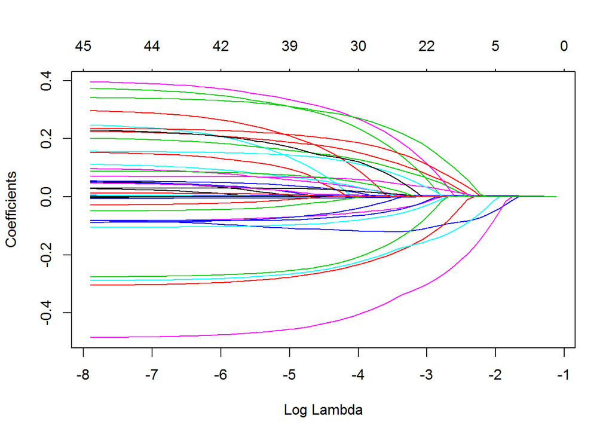

```r
#plot variable coefficients vs. shrinkage parameter lambda.
plot(glmmod,xvar="lambda")
```

```r
# Predictions are made with the test set in order to evaluate the chosen model.
xfactors_test <- model.matrix(stars ~ C(type, base=2) + takeout + reservation + outdoorseating + waiterservice + creditcards + goodforkids + goodforgroups + goodfordessert + goodforlatenight + goodforlunch + goodfordinner + goodforbrunch + goodforbreakfast + price + parking + noise + alcohol + wifi, testing)[,-1]
x_test <- as.matrix(data.frame(testing$review_count, testing$white, testing$black, testing$native_american, testing$asian, testing$other, testing$popdensity_zip, testing$income_zip, testing$education_zip, testing$age_zip, testing$positivity_net, xfactors_test))

rest_linear_lasso_pred <- predict(cvfit, x_test,s="lambda.1se")
rest_linear_lasso_rmse <- RMSE(testing$stars, rest_linear_lasso_pred)
rest_linear_lasso_rmse
```

```
## [1] 0.5811245
```

```r
rmse_results <- bind_rows(rmse_results,
                          data_frame(method="Restaurant Lasso Linear Regression",
                                     RMSE = rest_linear_lasso_rmse ))
```

### CART Modeling (Classification and Regreesion trees)

```r
rest_cart_fit <- rpart(stars ~ C(type, base=2) + review_count + takeout + reservation + outdoorseating + waiterservice + creditcards + goodforkids + goodforgroups + goodfordessert + goodforlatenight + goodforlunch + goodfordinner + goodforbrunch + goodforbreakfast + price + parking + noise + alcohol + white + black + native_american + asian + other + wifi + popdensity_zip + income_zip + education_zip + age_zip + positivity_net, data = training)

printcp(rest_cart_fit)
```

```
##
## Regression tree:
## rpart(formula = stars ~ C(type, base = 2) + review_count + takeout +
##     reservation + outdoorseating + waiterservice + creditcards +
##     goodforkids + goodforgroups + goodfordessert + goodforlatenight +
##     goodforlunch + goodfordinner + goodforbrunch + goodforbreakfast +
##     price + parking + noise + alcohol + white + black + native_american +
##     asian + other + wifi + popdensity_zip + income_zip + education_zip +
##     age_zip + positivity_net, data = training)
##
## Variables actually used in tree construction:
## [1] C(type, base = 2) positivity_net    review_count
##
## Root node error: 3385/8247 = 0.41045
##
## n= 8247
##
##         CP nsplit rel error  xerror     xstd
## 1 0.068637      0   1.00000 1.00032 0.016801
## 2 0.039571      1   0.93136 0.93581 0.015505
## 3 0.018190      2   0.89179 0.89638 0.014532
## 4 0.014371      3   0.87360 0.88526 0.014502
## 5 0.010643      4   0.85923 0.86726 0.014247
## 6 0.010000      5   0.84859 0.86388 0.014218
```

```r
rest_cart_fit$cptable[which.min(rest_cart_fit$cptable[,"xerror"]),"CP"]
```

```
## [1] 0.01
```

```r
pcart<- prune(rest_cart_fit, cp=0.01)
rest_cart_pred <- predict(pcart, testing)
rest_cart_rmse <- RMSE(testing$stars, rest_cart_pred)
rmse_results <- bind_rows(rmse_results,
                          data_frame(method="Restaurant CART Regression",
                                     RMSE = rest_cart_rmse ))
rest_cart_rmse
```

```
## [1] 0.60103
```

### Random Forest

```r
rest_rf_fit <- randomForest(stars ~ type + review_count + takeout + reservation + outdoorseating + waiterservice + creditcards + goodforkids + goodforgroups + goodfordessert + goodforlatenight + goodforlunch + goodfordinner + goodforbrunch + goodforbreakfast + price + parking + noise + alcohol + white + black + native_american + asian + other + wifi + popdensity_zip + income_zip + education_zip + age_zip + positivity_net, data = training)
```

```r
load(file = 'rest_rf_fit.rda')

variable_importance <- importance(rest_rf_fit)
tmp <- data_frame(feature = rownames(variable_importance),
                  Gini = variable_importance[,1]) %>%
  arrange(desc(Gini))
kable(tmp[1:15,])
```

| feature | Gini |
| --- | --- |
| review_count | 525.68276 |
| positivity_net | 346.92778 |
| type | 268.35777 |
| asian | 150.21146 |
| native_american | 143.30867 |
| popdensity_zip | 142.07340 |
| other | 139.35455 |
| education_zip | 134.57825 |
| black | 133.69755 |
| age_zip | 131.68838 |
| noise | 126.41165 |
| white | 124.83069 |
| income_zip | 120.33137 |
| parking | 101.01173 |
| price | 62.25462 |

We found that Variables used to be excluded in stepwise and Lasso were important in Random Forest, ‘black’, ‘income zip’, ‘age zip’, ‘other’ race, ‘white’, ‘native_american’ and ‘education zip’.

```r
rest_rf_pred <- predict(rest_rf_fit, testing)
rest_rf_rmse <- RMSE(testing$stars, rest_rf_pred)

rmse_results <- bind_rows(rmse_results,
                          data_frame(method="Restaurant Random Forest Regression",
                                     RMSE = rest_rf_rmse ))
rest_rf_rmse
```

```
## [1] 0.3382744
```

### Support Vector Machine (SVM)

```r
#The best SVM model is obtained by iteration through various costs.
rest_svm_fit2 <-tune(svm, stars ~ type + review_count + takeout + reservation + outdoorseating + waiterservice + creditcards + goodforkids + goodforgroups + goodfordessert + goodforlatenight + goodforlunch + goodfordinner + goodforbrunch + goodforbreakfast + price + parking + noise + alcohol + white + black + native_american + asian + other + wifi + popdensity_zip + income_zip + education_zip + age_zip + positivity_net, data = training, kernel="linear", ranges=list(cost=c(0.001,0.01,0.1, 1,5)))

summary(rest_svm_fit2) #The SVM tuning parameter findings
bestmodel <-rest_svm_fit2$best.model #The best model
```

```r
load(file = 'rest_svm_best.rda')
summary(bestmodel) #The best model results
```

```
##
## Call:
## best.tune(method = svm, train.x = stars ~ type + review_count +
##     takeout + reservation + outdoorseating + waiterservice +
##     creditcards + goodforkids + goodforgroups + goodfordessert +
##     goodforlatenight + goodforlunch + goodfordinner + goodforbrunch +
##     goodforbreakfast + price + parking + noise + alcohol + white +
##     black + native_american + asian + other + wifi + popdensity_zip +
##     income_zip + education_zip + age_zip + positivity_net, data = training,
##     ranges = list(cost = c(0.001, 0.01, 0.1, 1, 5)), kernel = "linear")
##
##
## Parameters:
##    SVM-Type:  eps-regression
##  SVM-Kernel:  linear
##        cost:  0.1
##       gamma:  0.0212766
##     epsilon:  0.1
##
##
## Number of Support Vectors:  7508
```

```r
#SVM Model Evaluation: Predictions are made with the test set in order to evaluate the chosen model.
rest_svm_pred <- predict(bestmodel, testing)
rest_svm_rmse <- RMSE(testing$stars, rest_svm_pred)
rmse_results <- bind_rows(rmse_results,
                          data_frame(method="Restaurant Support Vector Machine Regression",
                                     RMSE = rest_svm_rmse ))
rest_svm_rmse
```

```
## [1] 0.5805574
```

### Restricted dataset (without “Las Vegas”)

Las Vegas is likely to be different from other regions in terms of customer characteristics because most of customers are likely to be visitors. Therefore, we restricted the dataset to without Las Vegas.

```r
rest_no_lv <- restaurant %>% filter(!city== "Las Vegas")

inTrain_no_lv <- createDataPartition(y=rest_no_lv$stars, p=0.80, list=FALSE)
train_no_lv <- rest_no_lv[inTrain_no_lv,]
test_no_lv  <- rest_no_lv[-inTrain_no_lv,]
```

#### Restricted dataset (without “Las Vegas”) multivariable linear regression - stepwise

```r
rest_linear_fit2 <- lm(stars ~ C(type, base=2) + review_count + takeout + reservation + outdoorseating + waiterservice + creditcards + goodforkids + goodforgroups + goodfordessert + goodforlatenight + goodforlunch + goodfordinner + goodforbrunch + goodforbreakfast + price + parking + noise + alcohol + white + black + native_american + asian + other + wifi + popdensity_zip + income_zip + education_zip + age_zip + positivity_net, data = train_no_lv)

## choosing variables using stepwise methods
rest_linear_fit2_step <- step(rest_linear_fit2)
```

```r
summary(rest_linear_fit2_step)
```

```
##
## Call:
## lm(formula = stars ~ C(type, base = 2) + review_count + takeout +
##     reservation + outdoorseating + creditcards + goodfordessert +
##     goodforlatenight + goodforlunch + goodfordinner + goodforbrunch +
##     price + parking + noise + asian + income_zip + education_zip +
##     age_zip + positivity_net, data = train_no_lv)
##
## Residuals:
##      Min       1Q   Median       3Q      Max
## -2.03034 -0.34577  0.03277  0.37570  1.82864
##
## Coefficients:
##                       Estimate Std. Error t value Pr(>|t|)
## (Intercept)          3.289e+00  8.249e-02  39.871  < 2e-16 ***
## C(type, base = 2)1   4.028e-01  1.988e-01   2.026 0.042819 *
## C(type, base = 2)3   8.830e-02  2.741e-02   3.221 0.001284 **
## C(type, base = 2)4   4.778e-02  2.786e-02   1.715 0.086338 .
## C(type, base = 2)5   1.828e-01  3.872e-02   4.721 2.40e-06 ***
## C(type, base = 2)6   2.382e-01  3.684e-02   6.465 1.09e-10 ***
## C(type, base = 2)7  -7.334e-02  2.684e-02  -2.732 0.006313 **
## C(type, base = 2)8   7.788e-02  2.997e-02   2.598 0.009387 **
## C(type, base = 2)9   4.321e-01  7.906e-02   5.466 4.79e-08 ***
## C(type, base = 2)10  1.194e-01  3.059e-02   3.902 9.64e-05 ***
## C(type, base = 2)11  5.962e-01  1.783e-01   3.344 0.000830 ***
## C(type, base = 2)12  3.123e-01  7.913e-02   3.947 8.00e-05 ***
## review_count         1.169e-03  6.927e-05  16.879  < 2e-16 ***
## takeout             -7.315e-02  4.167e-02  -1.756 0.079223 .
## reservation         -2.806e-02  1.979e-02  -1.418 0.156332
## outdoorseating       2.919e-02  1.612e-02   1.811 0.070212 .
## creditcards         -2.888e-01  5.086e-02  -5.679 1.42e-08 ***
## goodfordessert       1.848e-01  4.572e-02   4.043 5.35e-05 ***
## goodforlatenight    -7.570e-02  3.279e-02  -2.308 0.021013 *
## goodforlunch         4.333e-02  1.719e-02   2.521 0.011729 *
## goodfordinner       -2.765e-02  1.916e-02  -1.443 0.149040
## goodforbrunch        8.141e-02  2.831e-02   2.876 0.004044 **
## price2              -1.046e-01  1.917e-02  -5.455 5.09e-08 ***
## price3               2.694e-02  5.063e-02   0.532 0.594691
## price4               2.327e-01  1.058e-01   2.200 0.027850 *
## parking1             1.750e-01  2.242e-02   7.805 7.02e-15 ***
## parking2             2.768e-01  2.969e-02   9.323  < 2e-16 ***
## noise1              -1.020e-01  1.966e-02  -5.189 2.19e-07 ***
## noise2              -2.856e-01  3.404e-02  -8.388  < 2e-16 ***
## noise3              -5.120e-01  4.997e-02 -10.248  < 2e-16 ***
## asian               -7.555e-03  2.048e-03  -3.689 0.000227 ***
## income_zip          -2.620e-06  1.378e-06  -1.901 0.057305 .
## education_zip        5.425e-01  1.931e-01   2.809 0.004992 **
## age_zip              2.071e-03  1.442e-03   1.436 0.151160
## positivity_net       5.552e-03  2.822e-04  19.676  < 2e-16 ***
## ---
## Signif. codes:  0 '***' 0.001 '**' 0.01 '*' 0.05 '.' 0.1 ' ' 1
##
## Residual standard error: 0.558 on 5864 degrees of freedom
## Multiple R-squared:  0.218,  Adjusted R-squared:  0.2135
## F-statistic: 48.08 on 34 and 5864 DF,  p-value: < 2.2e-16
```

```r
rest_linear_fit2_step_coef <- tidy(rest_linear_fit2_step, conf.int = TRUE)
rest_linear_pred2_step <- predict(rest_linear_fit2_step, test_no_lv)
rest_linear_rmse2_step <- RMSE(test_no_lv$stars, rest_linear_pred2_step)
rest_linear_rmse2_step
```

```
## [1] 0.5586334
```

```r
rmse_results <- bind_rows(rmse_results,
                          data_frame(method="Restaurant Stepwise Linear Regression (without Las Vegas)",
                                     RMSE = rest_linear_rmse2_step ))
```

#### Restricted dataset (without “Las Vegas”) multivariable linear regression - Lasso

```r
xfactors <- model.matrix(stars ~ C(type, base=2) + takeout + reservation + outdoorseating + waiterservice + creditcards + goodforkids + goodforgroups + goodfordessert + goodforlatenight + goodforlunch + goodfordinner + goodforbrunch + goodforbreakfast + price + parking + noise + alcohol + wifi, train_no_lv)[,-1]
x <- as.matrix(data.frame(train_no_lv$review_count, train_no_lv$white, train_no_lv$black, train_no_lv$native_american, train_no_lv$asian, train_no_lv$other, train_no_lv$popdensity_zip, train_no_lv$income_zip, train_no_lv$education_zip, train_no_lv$age_zip, train_no_lv$positivity_net, xfactors))

glmmod2<-glmnet(x,train_no_lv$stars,alpha=.5,family='gaussian')
cvfit2 <- glmnet::cv.glmnet(x, train_no_lv$stars)
rest_linear_fit2_lasso_coef <- coef(cvfit2, s = "lambda.1se")
print(rest_linear_fit2_lasso_coef)
```

```
## 47 x 1 sparse Matrix of class "dgCMatrix"
##                                         1
## (Intercept)                  3.2781557757
## train_no_lv.review_count     0.0010834130
## train_no_lv.white            .
## train_no_lv.black            .
## train_no_lv.native_american  .
## train_no_lv.asian           -0.0036217013
## train_no_lv.other            .
## train_no_lv.popdensity_zip   .
## train_no_lv.income_zip       .
## train_no_lv.education_zip    0.1296626564
## train_no_lv.age_zip          0.0001994702
## train_no_lv.positivity_net   0.0053409796
## C.type..base...2.1           .
## C.type..base...2.3           .
## C.type..base...2.4           .
## C.type..base...2.5           0.1114262806
## C.type..base...2.6           0.1272649717
## C.type..base...2.7          -0.1032642778
## C.type..base...2.8           .
## C.type..base...2.9           0.2603761853
## C.type..base...2.10          0.0027091680
## C.type..base...2.11          0.2744133825
## C.type..base...2.12          0.1521973049
## takeout                     -0.0120072906
## reservation                  .
## outdoorseating               0.0028449879
## waiterservice                .
## creditcards                 -0.2161155487
## goodforkids                  .
## goodforgroups                .
## goodfordessert               0.1052392075
## goodforlatenight            -0.0317192054
## goodforlunch                 0.0304414965
## goodfordinner                .
## goodforbrunch                0.0222633447
## goodforbreakfast             .
## price2                      -0.0796927440
## price3                       .
## price4                       0.0638875074
## parking1                     0.1051092726
## parking2                     0.1860457977
## noise1                      -0.0377861512
## noise2                      -0.2051167195
## noise3                      -0.4031621009
## alcohol                      .
## wifi1                        .
## wifi2                        .
```

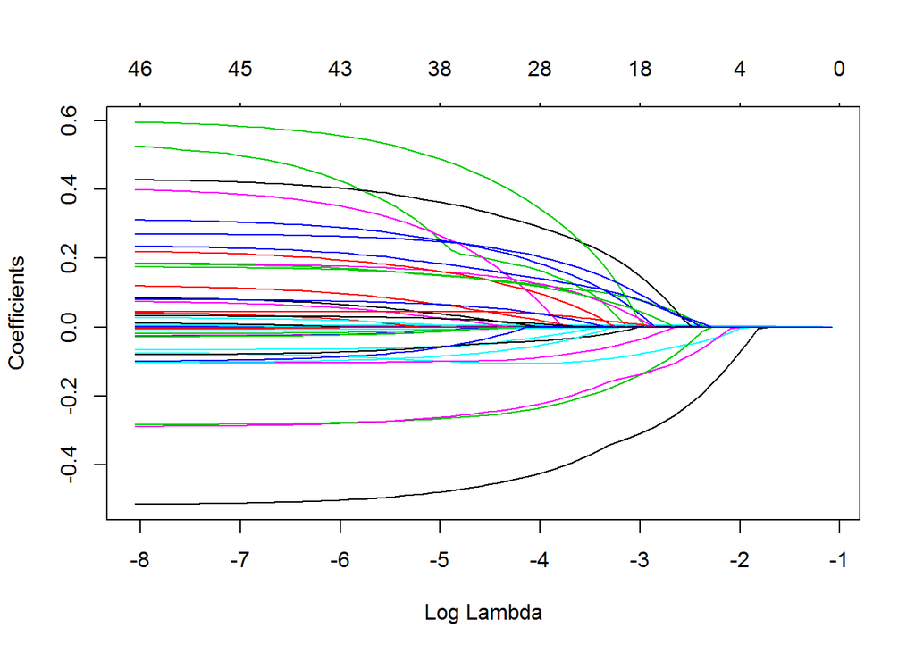

```r
#plot variable coefficients vs. shrinkage parameter lambda.
plot(glmmod2,xvar="lambda")
```

```r
xfactors_test <- model.matrix(stars ~ C(type, base=2) + takeout + reservation + outdoorseating + waiterservice + creditcards + goodforkids + goodforgroups + goodfordessert + goodforlatenight + goodforlunch + goodfordinner + goodforbrunch + goodforbreakfast + price + parking + noise + alcohol + wifi, test_no_lv)[,-1]
x_test <- as.matrix(data.frame(test_no_lv$review_count, test_no_lv$white, test_no_lv$black, test_no_lv$native_american, test_no_lv$asian, test_no_lv$other, test_no_lv$popdensity_zip, test_no_lv$income_zip, test_no_lv$education_zip, test_no_lv$age_zip, test_no_lv$positivity_net, xfactors_test))

rest_linear_lasso_pred2 <- predict(cvfit2, x_test,s="lambda.1se")
rest_linear_lasso_rmse2 <- RMSE(test_no_lv$stars, rest_linear_lasso_pred2)
rmse_results <- bind_rows(rmse_results,
                          data_frame(method="Restaurant Lasso Linear Regression (without Las Vegas)",
                                     RMSE = rest_linear_lasso_rmse2 ))
rmse_results %>% kable
```

| method | RMSE |
| --- | --- |
| Restaurant Stepwise Linear Regression | 0.5780128 |
| Restaurant Lasso Linear Regression | 0.5811245 |
| Restaurant CART Regression | 0.6010300 |
| Restaurant Random Forest Regression | 0.3382744 |
| Restaurant Support Vector Machine Regression | 0.5805574 |
| Restaurant Stepwise Linear Regression (without Las Vegas) | 0.5586334 |
| Restaurant Lasso Linear Regression (without Las Vegas) | 0.5625071 |